# 4. Greedy Algorithms I

4. Greedy Algorithms I

WU Xiaokun 吴晓堃

xkun.wu [at] gmail

2021/10/22

## Greedy idea

**Greedy decision**: builds up a solution in small steps, choosing a decision at each step *myopically* to optimize some underlying criterion.

- different measure leads to different solution.

It’s easy to invent greedy algorithms for almost any problem;

- finding cases in which they work well, and proving that they work well, is the interesting challenge.

# Coin changing

## Coin changing problem

**Goal**. Given U. S. currency denominations $\{ 1, 5, 10, 25, 100 \}$, devise a method to pay amount to customer using *fewest* coins.

**Coin Changing Problem**. Given a set $C = \{c_1, .., c_n\}$ of natural numbers and a target value $S$, find $n$ multipliers $M = \{m_1, .., m_n\}$ such that $\sum_{k = 1 .. n} m_k c_k = S$.

## Be a good cashier

Customer usually does not like handsful small changes.

**Ex**. $2.89

- $2 \times 100 + 3 \times 25 + 1 \times 10 + 4 \times 1$
- $289 \times 1$
  - customer probably complains to the manager.

**Cashier′s algorithm**. At each iteration, add coin of largest value that does not take us past the amount to be paid.

## Cashier′s algorithm

1. SORT $n$ denominations: $0 < c_1 < c_2 < \ldots < c_n$;
2. SET $m_1 = m_2 = \ldots = m_n = 0$;
3. WHILE ($0 < S$):
   1. $k$ = largest denomination $c_k$ such that $c_k \le S$;
   2. IF (no such $k$):
      1. RETURN “no solution”;
   3. ELSE:
      1. $S$ -= $c_k$;
      2. ++$m_k$;
4. RETURN $M$

## Quiz: Cashier′s algorithm

Is cashier’s algorithm optimal?

- Yes, greedy algorithms are always optimal.
- Yes, for any set of coin denominations $c_1 < c_2 < \ldots < c_n$ provided $c_1 = 1$.
- Yes, because of special properties of U.S. coin denominations.
- No.

No. See below.

## Arbitrary coin denominations

**Q**. Is cashier’s algorithm optimal for any set of denominations?

**A**. No. Consider U.S. postage: $1, 10, 21, 34, 70, 100, 350, 1225, 1500$.

- Cashier’s algorithm: $140 = 100 + 34 + 1 + 1 + 1 + 1 + 1 + 1$.
- Optimal: $140 = 70 + 70$.

**A**. No. It may not even lead to a feasible solution if $c_1 > 1$: $7, 8, 9$.

- Cashier’s algorithm: $15 = 9 + ?$.
- Optimal: $15 = 7 + 8$.

## Properties of optimal solution

**Property**. Number of pennies $\le 4$.  
**Pf**. Replace 5 pennies with 1 nickel.

**Property**. Number of nickels $\le 1$.

**Property**. Number of quarters $\le 3$.

**Property**. Number of nickels + number of dimes $\le 2$.  
**Pf**.

- Recall: $\le 1$ nickel.
- Replace 3 dimes and 0 nickels with 1 quarter and 1 nickel;
- Replace 2 dimes and 1 nickel with 1 quarter.

## Optimality of cashier′s algorithm

**Theorem**. Cashier’s algorithm is optimal for U.S. coins $\{ 1, 5, 10, 25, 100 \}$.  
**Pf**. [ by induction on amount to be paid S ]

- Consider optimal way to change $c_k \le S < c_{k+1}$: greedy takes coin $k$.
- We claim that any optimal solution must take coin $k$.
  - if not, it needs enough coins of type $c_1, \ldots, c_{k–1}$ to add up to $S$
  - table below indicates no optimal solution can do this
- Problem reduces to coin-changing $S – c_k$ cents, which, by induction, is optimally solved by cashier’s algorithm.

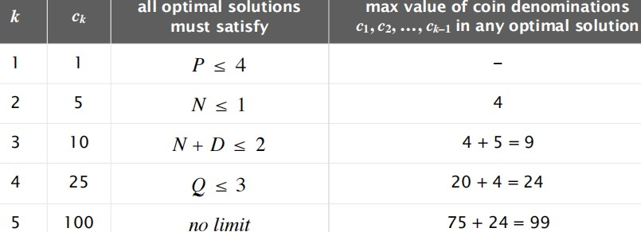

# Interval scheduling

## Interval scheduling problem

Consider $n$ subjects are sharing a *single* resource.

- lecture room, supercomputer, electron microscope, etc.

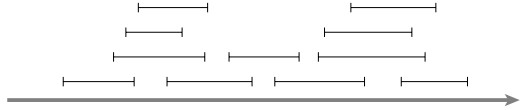

A set of $n$ **Job**s:

- job $j$: start at $s_j$ and finish at $f_j$
- two jobs are **compatible** if they do not overlap

**Interval Scheduling Problem**. Find maximum subset of mutually compatible jobs.

## Quiz: Interval scheduling

Which rule is optimal?

- [Earliest start time] Consider jobs in ascending order of $s_j$.
- [Shortest interval] Consider jobs in ascending order of $f_j – s_j$.
- [Earliest finish time] Consider jobs in ascending order of $f_j$.
- [Fewest incompatible] Pick the one has fewest number of incompatible requests.
- None of the above.

## Quiz: Interval scheduling (cont.)

Different rule leads to different greedy algorithm.

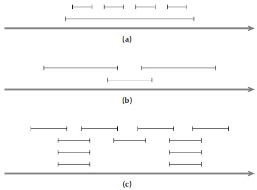

**Claim**. The earliest-finish-time-first algorithm is optimal.

## Earliest-finish-time-first algorithm

1. SORT jobs by finish times and renumber so that $f_1 \le f_2 \le \ldots \le f_n$;
2. $S = \emptyset$;
3. FOR $j = 1 .. n$:
   1. IF (job $j$ is compatible with $S$):
      1. $S = S \cup \{j\}$;
4. RETURN $S$;

**Proposition**. Can implement earliest-finish-time first in $O(n \log n)$ time.  
**Pf**.

- Keep track of job $j^\ast$ that was added last to $S$.
  - Job $j$ is compatible with $S$ iff $s_j \ge f_{j^\ast}$: $O(1)$ time.
- Sorting by finish times takes $O(n \log n)$ time.

## Earliest-finish-time-first: example

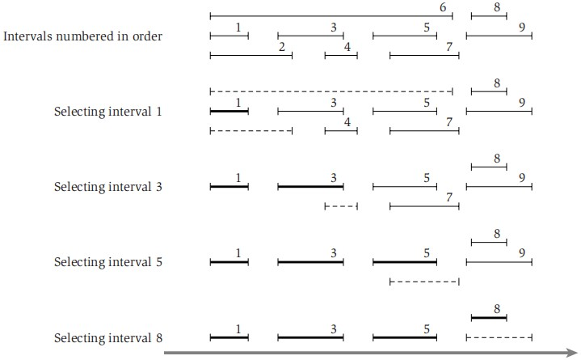

## Earliest-finish-time-first: Demo

## Optimality I: “stay ahead”

Remember: greedy rules *do not* always lead to optimal solution.

- when it does, typically reveal certain interesting structure of the problem.

**Stay ahead**: greedy algorithm is doing better in each step.

- attain local optimal under greedy criterion

**Claim**. Earliest-finish-time-first is doing better in each step.

- Let $A = \{i_1, .., i_k\}$ be jobs selected by greedy
- Let $\mathcal{O} = \{j_1, .., j_m\}$ be jobs selected optimal
- Show $|A| = k = m = |\mathcal{O}|$

## Earliest-finish-time-first: optimality

**Observation**. Greedy rule guarantees that $f(i_1) \le f(j_1)$.

**Lemma**. For all indices $r \le k$ we have $f(i_r) \le f(j_r)$.  
**Pf**. observed true for $r = 1$,

now suppose true for $r - 1$: $f(i_{r-1}) \le f(j_{r-1})$

- compatibility of $\mathcal{O}$: $f(j_{r-1}) \le s(j_{r})$
  - $f(i_{r-1}) \le s(j_{r})$
  - $j_r$ is a valid choice, when greedy selects $i_r$
    - $f(i_r) \le f(j_r)$ due to greedy rule

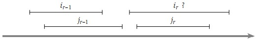

## Earliest-finish-time-first: optimality (cont.)

**Theorem**. The earliest-finish-time-first algorithm is optimal.  
**Pf**. otherwise $m > k$.

$f(i_k) \le f(j_k)$ by lemma

- $j_{k+1} : starts after $j_k$
  - $f(i_k) \le f(j_k) \le s(j_{k+1})$
  - algorithm stopped while there is a valid candidate, contradiction.

## Quiz: Weighted Interval Scheduling

Suppose that each job also has a positive weight and the goal is to find a maximum weight subset of mutually compatible intervals. Is earliest-finish-time-first algorithm still optimal?

- Yes, because greedy algorithms are always optimal.
- Yes, because the same proof of correctness is valid.
- No, because the same proof of correctness is no longer valid.
- No, because you could assign a huge weight to a job that overlaps the job with earliest finish time.

Weighted Interval Scheduling will be solved by Dynamic Programming optimally.

# Interval Partitioning

## Interval Partitioning Problem

Consider $n$ subjects are sharing *identical* resources.

- resources are plenty now, but do not waste

**Goal**: find minimum number of resources so that no incompatibility for each resource.

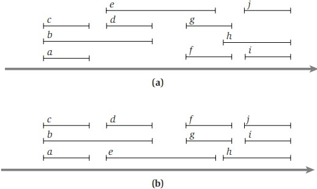

## Quiz: Interval Partitioning

Which rule is optimal?

- [Earliest start time] Consider jobs in ascending order of $s_j$.
- [Shortest interval] Consider jobs in ascending order of $f_j – s_j$.
- [Earliest finish time] Consider jobs in ascending order of $f_j$.
- [Fewest incompatible] Pick the one has fewest number of incompatible requests.
- None of the above.

## Depth of intervals

**Depth**. Maximum number that pass over any single point on the time-line.

**Claim**. In any instance of Interval Partitioning, the number of resources needed is at least the depth of intervals set.

**Key Observation**. If an algorithm *always* produce a schedule using resources *equal* to the depth, then it must be optimal.

- Number of resources needed $\ge$ depth.

## Proof of Optimality: “characteristic bound”

**“Characteristic bound”**: greedy algorithm *always* attain a certain characteristic value.

- if the value bounds *every possible* optimal solution, greedy must be optimal.
- **Key**: find the characteristic value of the problem.

**Claim**. Earliest-start-time-first algorithm uses a number of resources equal to the depth of intervals.

- let $D$ be the depth and $d$ the current allocations

## Earliest-start-time-first algorithm

1. SORT requests by start times and renumber so that $s_1 \le s_2 \le \ldots \le s_n$;
2. $d = 0$;
3. FOR $j = 1 .. n$:
   1. IF (request $j$ is compatible with resource $k$):
      1. schedule request $j$ with resource $k$;
   2. ELSE:
      1. ++$d$;
      2. schedule request $j$ with resource $d$;
4. RETURN schedule;

## Earliest-start-time-first: Demo

## Earliest-start-time-first: analysis

**Proposition**. The earliest-start-time-first algorithm can be implemented in $O(n \log n)$ time.  
**Pf**.

- Sorting by start times takes $O(n \log n)$ time.
- Store resources in a `priority queue` (`key` = *finish time of its last request*).
  - to allocate a new resource, `INSERT` resource onto priority queue.
  - to schedule request $j$ in resource $k$, `INCREASE-KEY` of resource $k$ to $f_j$.
  - to determine whether request $j$ is compatible with any resource, compare $s_j$ to `FIND-MIN`
- Total # of priority queue operations is $O(n)$; each takes $O(\log n)$ time.

**Remark**. This implementation chooses a resource $k$ whose *finish time of its last request is the earliest*.

- already sorted by start time

## Earliest-start-time-first: optimality

**Observation**. Earliest-start-time-first algorithm never schedules two incompatible requests with same resource; every request will be fulfilled.

**Theorem**. Earliest-start-time-first algorithm is optimal.  
**Pf**.

- When algorithm terminates, $d$ resources are allocated in total.
  - Resource $d$ is allocated because we needed to schedule a request, say $j$, that is incompatible with a request in each of $d – 1$ other resources.
  - Thus, these $d$ requests each end after $s_j$.
  - Since we sorted by start time, each of these incompatible requests start no later than $s_j$.
  - Thus, we have $d$ requests overlapping at time $s_j + \epsilon$.
    - By definition of depth, $d \le D$
- Key observation $\Rightarrow$ all schedules use $\ge D$ resources.

# Minimize Lateness

## Scheduling to minimize lateness

Consider $n$ subjects are sharing a *single* resources.

- job $j$ requires $t_j$ unit time and due at $d_j$
  - determine start time $s_j$, so finish at $f_j = s_j + t_j$
- **Lateness**: $l_j = \max\{0, f_j - d_j\}$

**Goal**: minimize the **maximum lateness**: $L = \max_j l_j$.

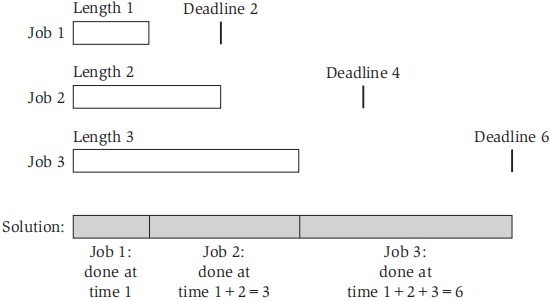

## Quiz: Minimize Lateness

Which order minimizes the maximum lateness?

- [shortest processing time] Ascending order of processing time $t_j$.
- [smallest slack] Ascending order of slack: $d_j – t_j$.
- [earliest deadline first] Ascending order of deadline $d_j$.
- None of the above.

shortest processing time

- $t_1 = 1, d_1 = 100$
- $t_2 = 10, d_2 = 10$: optimal

smallest slack

- $t_2 = 10, d_2 = 10$
- $t_1 = 1, d_1 = 2$: best

length is not even related?

## Earliest-deadline-first: algorithm

1. SORT jobs by due times and renumber so that $d_1 \le d_2 \le \ldots \le d_n$;
2. $t = 0$;
3. FOR $j = 1 .. n$:
   1. Assign job $j$ to interval $[t, t + t_j]$;
   2. $s_j = t$; $f_j = t + t_j$;
   3. $t$ = $t$ + $t_j$;
4. RETURN intervals $[s_1, f_1], [s_2, f_2], \ldots, [s_n, f_n]$;

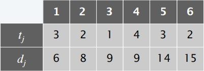

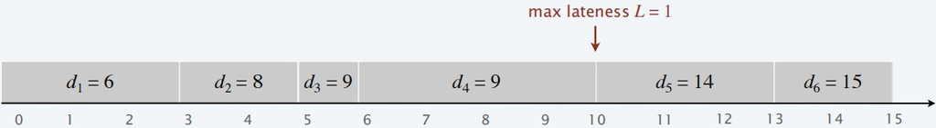

## Minimize Lateness: no idle time

**Observation 1** Earliest-deadline-first has no “gap”.

- each interval starts just when the previous ends.

**Idle time**: there is work to be done, yet machine is sitting idle.

**Observation 2**. There exists an optimal schedule with no idle time.

- given an optimal schedule, just move each interval earlier to squeeze out gaps.

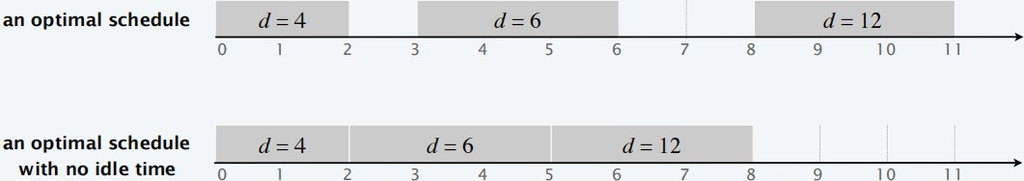

## Optimality II: exchange argument

Note: no-idle-time is a common property shared by greedy and optimal.

**Exchange argument**: given an optimal $\mathcal{O}$, gradually modify it

- preserving optimality at each step
- eventually transforming it into a solution identical to greedy

**Def**. Given a schedule $S$, an **inversion** is a pair of jobs $i$ and $j$ such that: $d_i < d_j$ but $j$ is scheduled before $i$.

| .. | $d_i$ | .. | $d_j$ | .. |
| --- | --- | --- | --- | --- |
| .. | j | .. | i | .. |

**Observation 3** Earliest-deadline-first has no inversion (and no idle time).

## Exchange argument: properties to keep

**Claim**. All schedules with no inversions and no idle time have the same maximum lateness.  
**Pf**.

- only differ in the order of jobs with identical deadlines.
  - they are scheduled consecutively
- excluding these jobs, the order is fixed (no inversion) and compact (no idle time)

**Key to show optimality**: there is an optimal schedule that has no inversions and no idle time.

- start with any optimal schedule with no idle time
- convert it into schedule with no inversion, without increasing maximum lateness

## Optimality: adjacent inversion

**Observation 4**. If an idle-free schedule has an inversion, then it has an adjacent inversion (scheduled consecutively).  
**Pf**. Let $i–j$ be the *closest* inversion.  
Let $k$ be element immediately to the right of $j$.

- $[ j > k ]$ Then $j–k$ is an adjacent inversion.
- $[ j < k ]$ Then $i–k$ is a *closer* inversion since $i < \ldots < j < k$, contradiction.

| .. |  | $d_i$ |  | .. | $d_j$ | $d_k$ | .. |
| --- | --- | --- | --- | --- | --- | --- | --- |
| .. | k | j |  | .. | i |  | .. |
| .. |  | j | k | .. | i |  | .. |

## Optimality: swap

**Lemma**. Exchanging two adjacent, inverted jobs $i$ and $j$ reduces the number of inversions by $1$ and does not increase max lateness.  
**Pf**. Let $l$ be the lateness before swap, and let $lʹ$ be it afterwards.

| \ | .. | $d_i$ | .. | $d_j$ | .. |
| --- | --- | --- | --- | --- | --- |
| before swap | .. | j | .. | i | .. |
| after swap | .. | i | .. | j | .. |

## Earliest-deadline-first: optimality

**Theorem**. The earliest-deadline-first schedule is optimal.  
**Pf**.

- an optimal schedule with no inversions and no idle time exists
  - all schedules with no inversions and no idle time have same maximum lateness
  - earliest-deadline-first always produces such schedule

## Greedy analysis strategies

**Greedy algorithm stays ahead**. Show that after each step of greedy algorithm, its solution is at least as good as any other algorithm’s.

**Characteristic bound**. Discover a simple characteristic bound asserting that every possible solution must have a certain value. Then show that your algorithm always achieves this bound.

**Exchange argument**. Gradually transform any solution to the one found by greedy algorithm without hurting its quality.

Other greedy algorithms. Gale–Shapley, Kruskal, Prim, Dijkstra, Huffman, etc.

## Interested in solving problem?

LeetCode: https://leetcode.com

# Optimal Caching

## Caching

**Caching**.

- Cache with capacity to store $k$ items.
- Sequence of $m$ item requests $d_1, d_2, \ldots, d_m$.
- Cache hit: item in cache when requested.
- Cache miss: item not in cache when requested.
  - must evict some item from cache and bring requested item into cache

**Applications**. CPU, RAM, hard drive, web, browser, etc.

## Cache maintenance

**Goal**. Eviction schedule that minimizes the number of evictions.

**Ex**. $k = 2$, initial cache = ab, requests: a, b, c, b, c, a, b.

- Optimal eviction schedule: 2 evictions.

| a | b | c | b | c | a | b |
| --- | --- | --- | --- | --- | --- | --- |
| a | a | **c** | c | c | **a** | a |
| b | b | b | b | b | b | b |

## Cache maintenance: greedy options

**LIFO/FIFO**. Evict item brought in least (most) recently.

**LRU**. Evict item whose most recent access was earliest.

**LFU**. Evict item that was least frequently requested.

## Farthest-in-future

**Farthest-in-future**. Evict item in the cache that is not requested until farthest in the future.

**Theorem**. [Bélády 1966] FF is optimal eviction schedule.

- as usual, design is simple but analysis is subtle

**FF**: 2 evictions

| a | b | c | d | a | d | e | a | d | b | c |
| --- | --- | --- | --- | --- | --- | --- | --- | --- | --- | --- |
| a | a | a | a | a | a | a | a | a | a | a |
| b | b | b | b | b | b | **e** | e | e | e | e |
| c | c | c | **d** | d | d | d | d | d | d | d |

## Farthest-in-future: example

**FF**: 2 evictions

| a | b | c | d | a | d | e | a | d | b | c |
| --- | --- | --- | --- | --- | --- | --- | --- | --- | --- | --- |
| a | a | a | a | a | a | a | a | a | a | a |
| b | b | b | b | b | b | **e** | e | e | e | e |
| c | c | c | **d** | d | d | d | d | d | d | d |

Note: other options may be just as good.

| a | b | c | d | a | d | e | a | d | b | c |
| --- | --- | --- | --- | --- | --- | --- | --- | --- | --- | --- |
| a | a | a | a | a | a | a | a | a | a | a |
| b | b | b | **d** | d | d | d | d | d | d | d |
| c | c | c | c | c | c | **e** | e | e | e | e |

So why FF is optimal?

## Exchange argument: intuition

**Observation**. Swapping one decision for another does not change cost.

- the other decision will be taken anyway

**Def**. A **reduced** schedule does minimal amount of work necessary in a given step.

- only bring $d$ into cache if there is a request to $d$, and $d$ is missing
  - exactly the number of misses
- sometimes also called “lazy” strategy

Note: FF is clearly reduced

- Key: prove for every non-reduced schedule, there is an equally good reduced schedule

## Reduced schedule

**Claim**. Given any unreduced schedule $S$, can transform it into a reduced schedule $Sʹ$ with no more evictions.  
**Pf**. [induction on step $j$] case-by-case discussion:

- Case 1: $S$ bring in $d$ without a request
- Case 2: $S$ bring in $d$ even thought $d$ is in cache
- if multiple happens, apply each in turn
  - Case 1 should applied first, which may trigger Case 2

Or just “pretends” to cache but actually leaves $d$ out

- only bring in $d$ when requested.

## Optimality of FF

Note: for any reduced schedule, the number of items that are brought in is exactly the number of misses.

Let $S_{FF}$ denote schedule produced by Farthest-in-Future,  
Let $S^\ast$ denote a schedule that incurs minimum possible number of misses

- now gradually “transform” schedule $S^\ast$ into $S_{FF}$, one eviction decision at a time
- without increasing number of misses.

**Theorem**. FF is optimal eviction algorithm, since it incurs no more misses than any other schedule.

**Lemma**. If $S_{FF}$ and $S$ make same eviction decision through first $j$ steps, then there is a reduced schedule $S'$ that make same eviction decision as $S$ through first $j + 1$ steps, and incurs no more misses than $S$.

## Proving Optimality of FF

$S_{FF}$ and $S$ have same cache contents.  
Let $d$ denote the item requested in step $j + 1$.

- $d$ in cache: $S' = S$
- $S_{FF}$ and $S$ evict same item: $S' = S$
- $S_{FF}$ evict $e$, $S$ evict $f \ne e$
  - $S'$ should evict $e$, but sync with $S$ ASAP
    - $S'$ agrees with $S_{FF}$ through first $j + 1$ steps
    - show having $f$ is no worse than having $e$
  - from step $j+2$ onward, $S'$ behaves exactly like $S$, until …

| S |  |  | steps | S’ |  |  |
| --- | --- | --- | --- | --- | --- | --- |
| same | e | f | step j | same | e | f |
| same | e | d | step j + 1 | same | d | f |

## Proving Optimality of FF (cont.)

… until following happens *for the first time*:

- A. request to $g (\ne e, f)$ not in cache, and $S$ evict $e$
  - $S'$ evict $f$
- request to $f$, and $S$ evict $e'$
  - B. if $e' = e$: no change
  - C. otherwise: $S'$ evict $e'$ and take $e$
    - $S'$ may not reduced: transform it to a reduction
- request to $e$: impossible
  - $S_{FF}$ evict $e$ in step $j+1$, request to $f$ must come earlier

| S |  |  | steps | S’ |  |  |
| --- | --- | --- | --- | --- | --- | --- |
| same | e | d | step j + 1 | same | d | f |
| same | g | d | step A | same | d | g |
| same | f | d | step B | same | d | f |
| same | e | d | step C | same | d | e |

## Cache maintenance: extensions

Problem of FF: in practice, generally impossible to know future request order.

- often used as baseline for offline comparisons
- Experimentally, Least-Recently-Used (LRU) is the best
- Caching is among most fundamental online problems in CS.